# ggplot graphics

Day 4

## Exploratory data analysis (EDA)

- Oftentimes, real world data is messy
- Ex: you come up with a thesis topic and write down all the theory and statistical analysis you want to perform
  - You find a relevant dataset, but should you trust it?
- With large datasets, unrealistic to go through and check all the data
- Plotting a few key relationships can help us determine how usable our data is
- ggplot is your best friend when it comes to EDA!

## `ggplot2`: a grammar for graphics

- created by Hadley Wickham
- purposefully written to follow good graphing taxonomy
- allows you to create a graph in small, *readable* code chunks
- install the `ggplot2` package on your computer (if needed)

```r
> library(ggplot2)
> packageVersion("ggplot2")
[1] '3.3.5'
```

- Note: you can also create plots in `base R`, but we won’t cover that
- `ggplot` has some start up costs but saves time in the long run

## `ggplot2` grammar

- If you are really interested in the theory of Data Visualization, see Ch. 2
  - Basic idea is that there is a hierarchy of how we notice graphical features
- ggplot attempts to follow that hierarchy

```
ggplot(data) +    # data
  <geometry_funs>(aes(<variables>)) + # aesthetic variable mapping
  <label_funs> +  # add context
  <facet_funs> +  # add facets (optional)
  <coordinate_funs> +  # play with coords (optional)
  <scale_funs> + # play with scales (optional)
  <theme_funs> # play with axes, colors, etc (optional)
```

- can **layer** geometry functions
- can plot **stats** from raw data

## `Survey` data

- the dataset `Survey` provides student data from a survey:

```r
> survey <- read.csv("https://raw.githubusercontent.com/mgelman/data/master/Survey.csv")
```

- Look first at GPA (Q15) and possible sci or non-sci major (Q16)

## Data

- The first layer sets the graphical environment

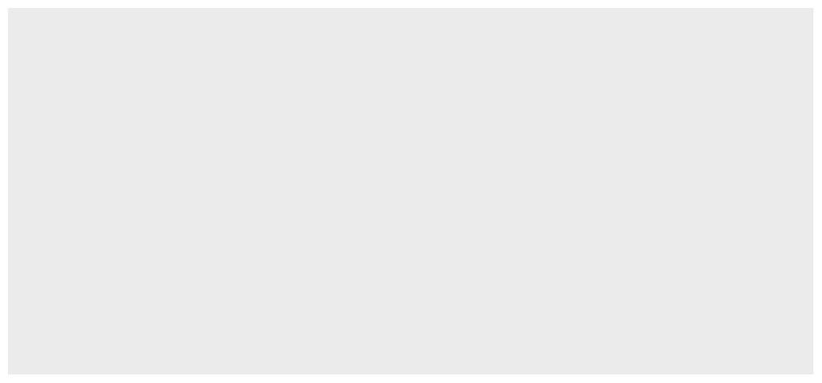

```r
> ggplot(data=survey)
```

## Aesthetics

- Aesthetics describes the mapping of variables to your graph
  - for numeric, default scale is Cartesian
- `aes` aesthetics can also be given in the `ggplot` command

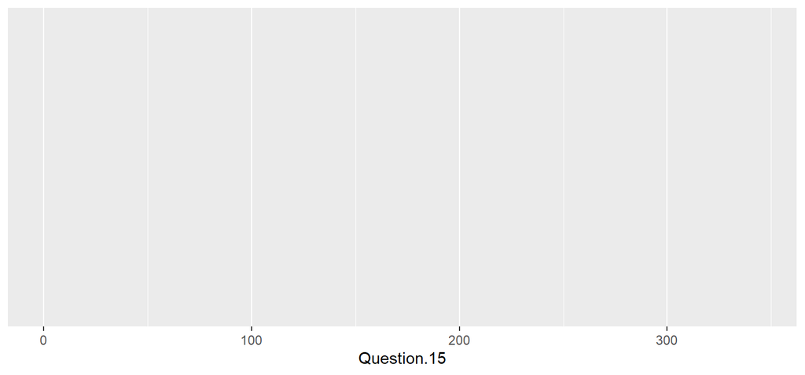

```r
> ggplot(data=survey, aes(x=Question.15))
```

## Geometry

- The geometry determines what form the plot has
- What type of plot would be useful here?
  - Here a `histogram` makes sense:

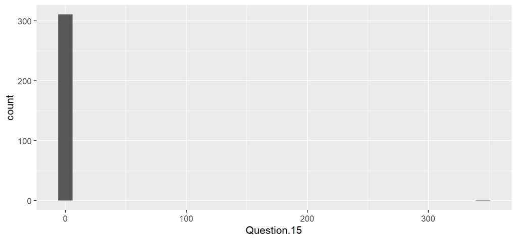

```r
> ggplot(data=survey, aes(x=Question.15)) + geom_histogram()
```

## EDA for data clean up

- Obviously there were some typos in the GPA data.
- Subset the data so only cases with a reasonable GPA are included.

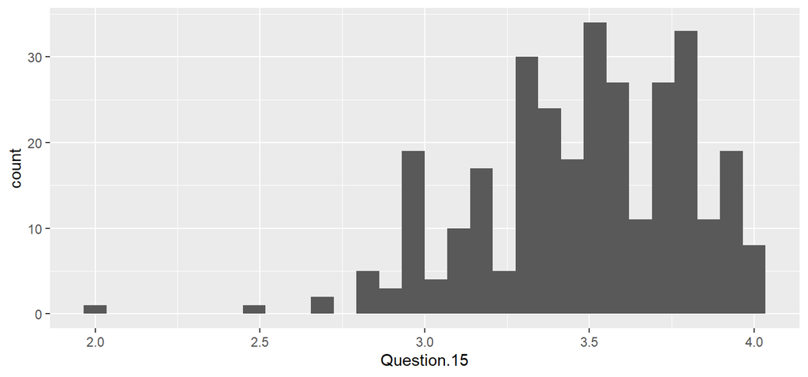

```r
> survey <- survey[survey$Question.15 <=4.0 & survey$Question.15 >0,]
> ggplot(data=survey, aes(x=Question.15)) + geom_histogram()
```

## Faceting

- Can add a third variable, science or non-sci major (Q16), with a facet:

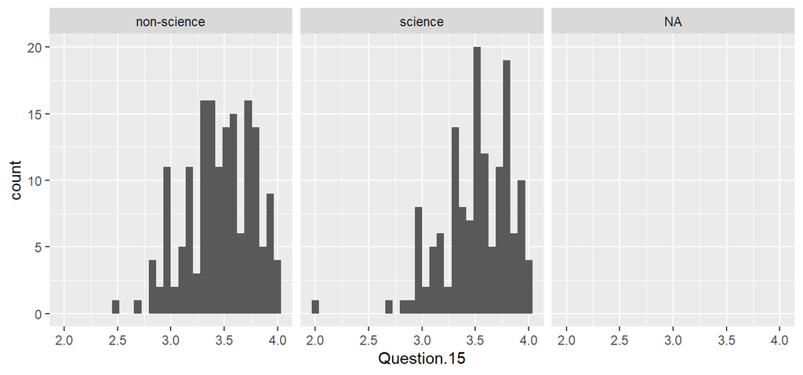

```r
> ggplot(data=survey, aes(x=Question.15)) + geom_histogram() + facet_wrap(~Question.16)
```

- Note: need `~` before the variable for `facet_wrap()`

## Another option

- Could also use side-by-side boxplots:

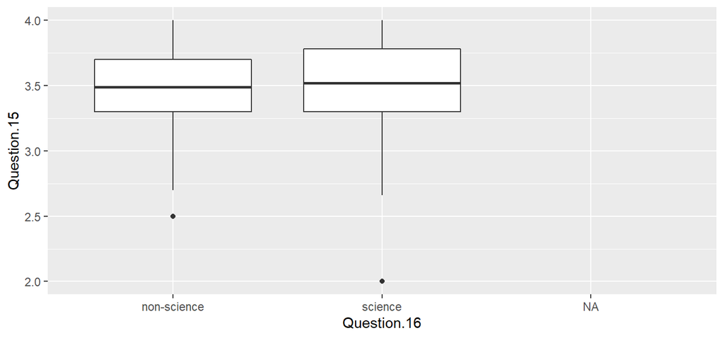

```r
> ggplot(data=survey, aes(y=Question.15, x=Question.16)) + geom_boxplot()
```

- This is where ggplot shines. Very easy to change the plot

## `ggplot` and `NA`’s

- Need to omit `NA` rows from data if you want them omitted from your graphics

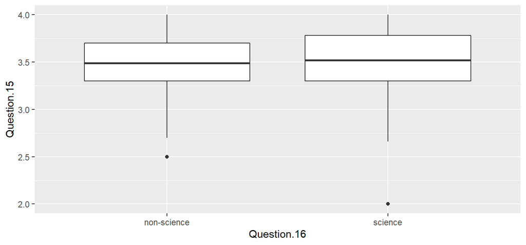

```r
> survey <- survey[!is.na(survey$Question.16),]
> ggplot(data=survey, aes(y=Question.15, x=Question.16)) + geom_boxplot()
```

## Adjusting coordinates

- We can flip the x/y coordinates (`boxplot` always wants `x` to be categorical and `y` numeric)

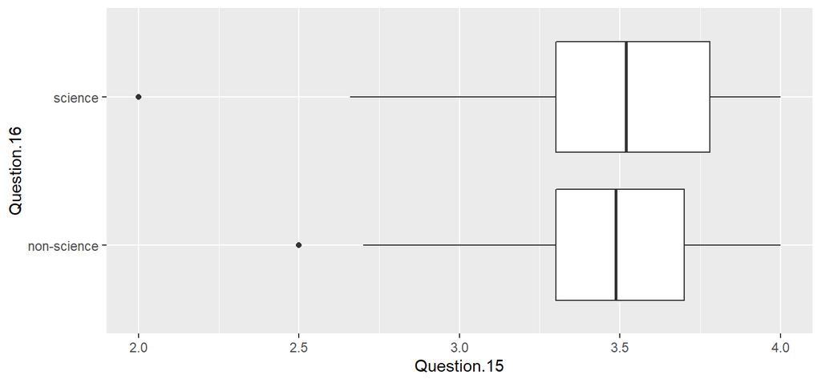

```r
> ggplot(data=survey, aes(y=Question.15, x=Question.16)) + geom_boxplot() + coord_flip()
```

## Context! Add labels

- Options include `ggtitle` and `labs`, change text size too

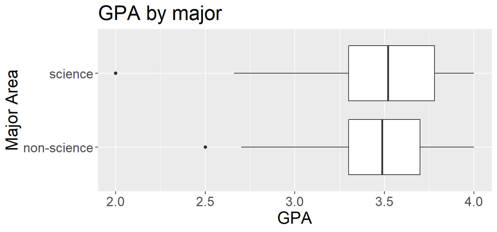

```r
> ggplot(data=survey, aes(y=Question.15, x=Question.16)) + geom_boxplot() + coord_flip() +
+   labs(title="GPA by major", x="Major Area", y="GPA") +
+   theme(text=element_text(size=18))
```

## How to proceed

- Get to know basic command structure (`ggplot + geom`)
  - Use cheat sheet to see `aes` options for each `geom`
  - `help`…`cheat sheets`
- Then add context layers: labels, font sizes, etc
- `?theme`: non-data features (fonts, legends, axes)
- `?scale_`: scale (x,y,fill, shape) data features

## Scatterplot

- The previous example looks at the properties of **one** variable
- Now, let’s look at the relationship between **two** variables
  - number of facebook friends (Q12) and GPA (Q15)

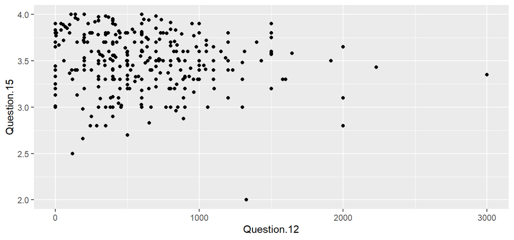

```r
> ggplot(survey, aes(x=Question.12,y=Question.15)) + geom_point()
```

## Scatterplot

Change symbol size and shape

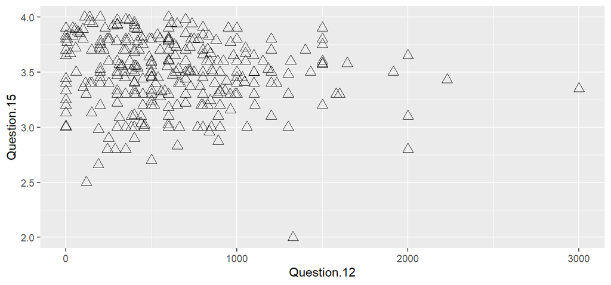

```r
> ggplot(survey, aes(x=Question.12,y=Question.15)) + geom_point(size=3,shape=2)
```

## Scatterplot

Change symbol shape by `major` (Q16): requires `aes` argument!

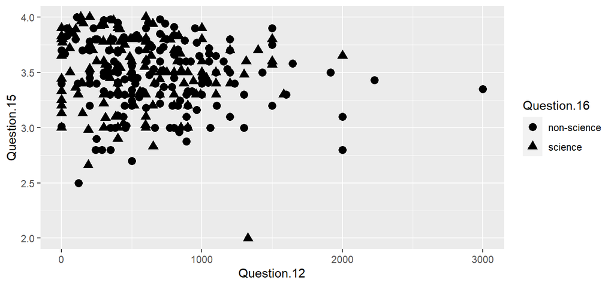

```r
> ggplot(survey, aes(x=Question.12,y=Question.15)) +
+   geom_point(aes(shape=Question.16), size=3)
```

## Scatterplot

Change symbol color by `major` (Q16): requires `aes` argument!

- the `color` is the `discrete` variable “major”, that is why `scale_color_discrete` is used

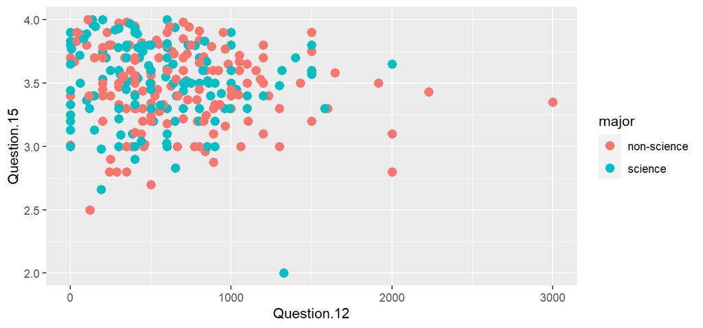

```r
> ggplot(survey, aes(x=Question.12,y=Question.15)) +
+   geom_point(aes(color=Question.16), size=3) + scale_color_discrete(name="major")
```

## Scatterplot

Change symbol size by number of tv hours/week (Q14): requires `aes` argument!

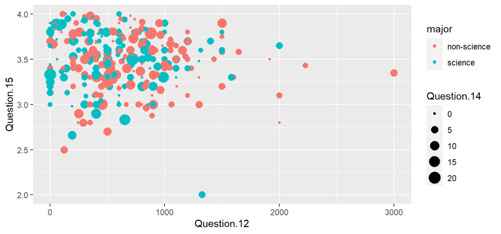

```r
> ggplot(survey, aes(x=Question.12,y=Question.15)) +
+   geom_point(aes(color=Question.16, size=Question.14)) + scale_color_discrete(name="major")
```

## Scatterplot

The `size` is the `continuous` variable tv, that is why `scale_size_continous` is used

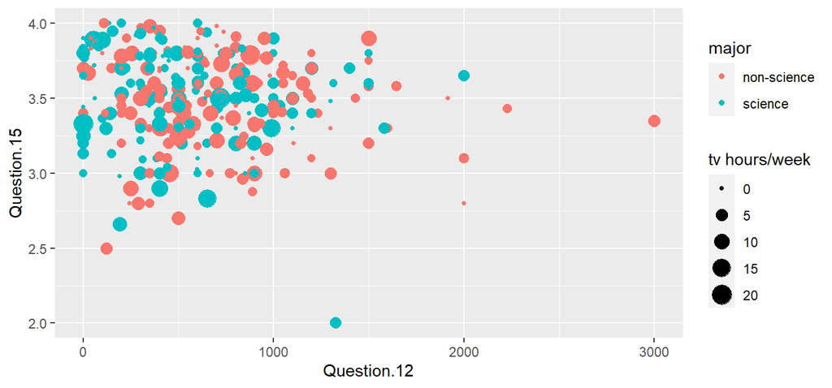

```r
> ggplot(survey, aes(x=Question.12,y=Question.15)) +
+   geom_point(aes(color=Question.16, size=Question.14)) + scale_color_discrete(name="major") +
+   scale_size_continuous(name="tv hours/week")
```